# Donor Profile: Japan for UNHCR

## Transaction Volatility

Japan’s average transaction amount of $739K across approximately 92 transactions annually starkly contrasts with the Top 10 donors’ $2.9M average over nearly 587 transactions, demonstrating under-leveraged financial engagement. This pronounced funding volatility presents both challenge and strategic priority: the irregular flow risks disrupting program continuity while highlighting significant potential for scaled impact. Investing in stabilizing and scaling Japan’s funding can yield an impact multiplier effect through enhanced predictability and increased transaction frequency, directly advancing emergency response and resilience objectives. Immediate executive action should prioritize targeted partnership strategies to deepen donor engagement with Japan, leveraging this data to articulate clear ROI and accountability frameworks. Doing so will unlock new funding trajectories, mitigate risk from volatility, and position Japan as a strategic growth partner, ultimately accelerating UNHCR’s mission delivery. Decision-makers must seize this moment to convert data-driven insights into catalytic investments that amplify resource mobilization and operational effectiveness.

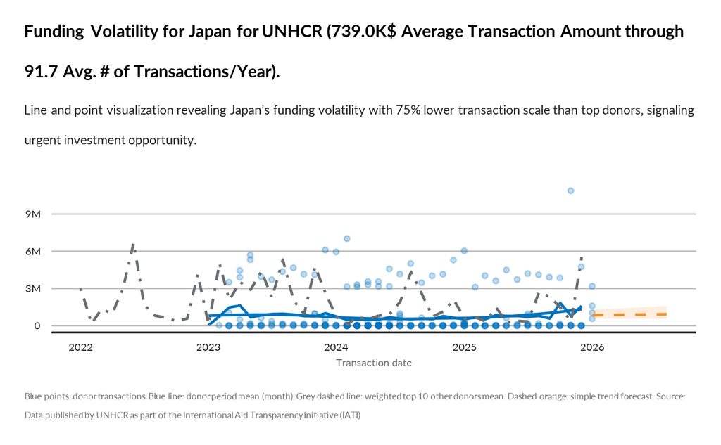

TRUE